**Universidade Federal de Alagoas - UFAL**

**Instituto de Computação - IC**

**Engenharia de Computação**

**Processamento Digital de Imagens e Computação Gráfica**

**Prof**.: Tiago Vieira

**Aluno**: Valério Nogueira Rodrigues Júnior

Data: 02/05/2022

# AB1

```python
import cv2
import numpy
from matplotlib import pyplot
```

## Questão 1

O sensor de uma câmera digital específica contém $2016\times3024(H\times W)$ pixels. A geometria do sensor é idêntica a de uma câmera 35mm tradicional (com uma imagem de tamanho $24\times36$mm) exceto por ser 1.6 vezes menor. Calcule a resolução deste sensor digital em *dpi*.

```python
h, w = 2016, 3024
# Conversão de cm para pol (talvez o fator esteja errado)
inches = 3.6 / 2.14
dpi = int(w / inches)
print(f'DPI = {dpi}')
```

```
DPI = 1797
```

## Questão 2

Determine o número de *bytes* necessários para armazenar:

### Uma imagem binária não comprimida de tamanho $4000\times3000$ pixels.

```python
size = 4000 * 3000
print(f'{size} bytes')
```

```
12000000 bytes
```

### Uma imagem colorida no espaço de cor RGB de tamanho $640\times480$ pixels usando 8, 10 ou 12 bits por canal de cor

```python
bits_per_channel = (8, 10, 12)
for bpc in bits_per_channel:
    # W * H * N_CHANNELS * BITS_PER_CHANNEL = tamanho em bits
    # Divide por 8 para transformar em bytes
    size = int((640 * 480 * 3 * bpc) / 8)
    print(f'{bpc} bits/canal = {size} bytes')
```

```
8 bits/canal = 921600 bytes
10 bits/canal = 1152000 bytes
12 bits/canal = 1382400 bytes
```

## Questão 3

Discorra sobre alguma aplicação de diagnóstico médico nuclear em que o paciente ingere um isótopo radioativo

## Questão 4

Explique:

### Para que serve e qual o princípio de funcionamento da equalização de histograma?

Para uniformizar a distribuição dos valores de intensidade da imagem. O príncipio é que os valores de intensidade de imagem podem ser vistos como relativos, assim podemos modificar o intervalo em que eles estão contidos para destacar detalhes antes imperceptíveis (ex.: `vmax` e `vmin` em `pyplot.imshow`)

### Em que situação típica a equalização de histograma não fornece um resultado satisfatório e qual seria uma alternativa viável indicada para atacar esse caso específico?

Quando há uma concentração muito alta na imagem de pixels escuros, pois assim a distribuição cumulativa fica alta desde o inicio do processo e o resultado é prejudicado. Podemos dividir a imagem e aplicar a equalização em partes específicas

## Questão 5

Considerando a imagem `Fruits-RGB.tif`, implemente uma alteração nos canais R, G e B de forma que o aspecto visual das maçãs passe a se tornar mais semelhante ao aspecto visual de pêras.

```python
fruits = cv2.imread('Fruits-RGB.tif', cv2.IMREAD_COLOR)
fruits = cv2.cvtColor(fruits, cv2.COLOR_BGR2RGB)
```

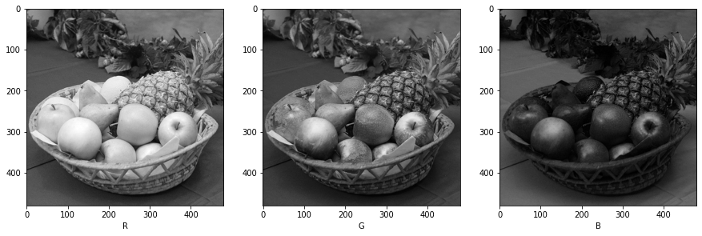

```python
# Analisando os canais da imagem individualmente
r, g, b = cv2.split(fruits)

fig, ax = pyplot.subplots(1, 3, figsize=(15, 5))
ax[0].imshow(r, cmap='gray', vmin=0, vmax=255)
ax[0].set_xlabel('R')
ax[1].imshow(g, cmap='gray', vmin=0, vmax=255)
ax[1].set_xlabel('G')
ax[2].imshow(b, cmap='gray', vmin=0, vmax=255)
ax[2].set_xlabel('B')

pyplot.show()
```

Como podemos ver, as maçãs possuem uma intensidade alta no canal R, porém uma intensidade menor que a das pêras no canal G

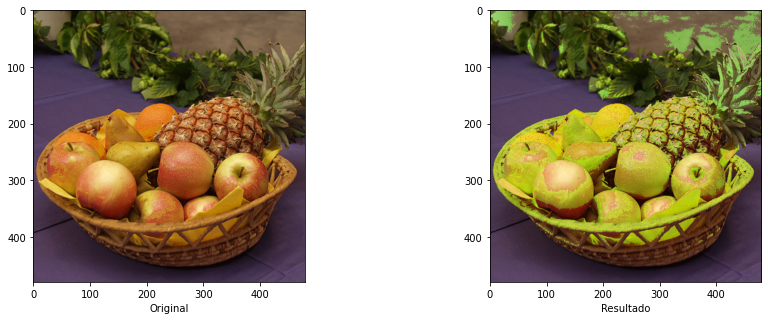

```python
g[(r[:, :] > 125) * (g[:, :] < 150)] += 75
result = cv2.merge((r, g, b))

fig, ax = pyplot.subplots(1, 2, figsize=(15, 5))
ax[0].imshow(fruits)
ax[0].set_xlabel('Original')
ax[1].imshow(result)
ax[1].set_xlabel('Resultado')

pyplot.show()
```

## Questão 6

Dada a imagem $f(x,y)$ (arquivo de imagem: `ten-objects.tif`), faça o que se pede:

### Obtenha $\rho(x, y)=R_\theta\{f(x, y)\}$ correspondente à uma rotação de $f(x, y)$ de um ângulo $\theta$

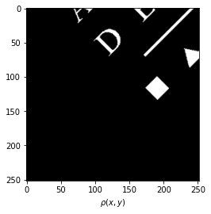

```python
lena = cv2.imread('ten-objects.tif')

center = (0, 0)
theta = 45.0
m = cv2.getRotationMatrix2D(center, theta, 1.0)
rho = cv2.warpAffine(lena, m, lena.shape[:-1])

pyplot.imshow(rho)
pyplot.xlabel('$\\rho (x, y)$')
pyplot.show()
```

## Obtenha $g_1(x, y) = \triangle^2\rho(x, y)$ resultante da aplicação do operador Laplaciano à imagem rotacionada $\rho(x, y)$

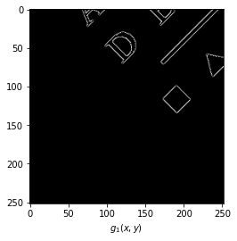

```python
g1 = cv2.Laplacian(rho, 8)

pyplot.imshow(g1)
pyplot.xlabel('$g_1(x,y)$')
pyplot.show()
```

## Obtenha $g_2(x, y)=R_\theta\{\triangle^2f(x, y)\}$ que é a rotação do laplaciano da imagem original

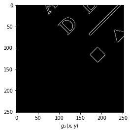

```python
g2 = cv2.warpAffine(cv2.Laplacian(lena, 8), m, lena.shape[:-1])

pyplot.imshow(g1)
pyplot.xlabel('$g_2(x,y)$')
pyplot.show()
```

## Apresente $g_1$ e $g_2$ lado a lado. O que você conclui sobre o resultado?

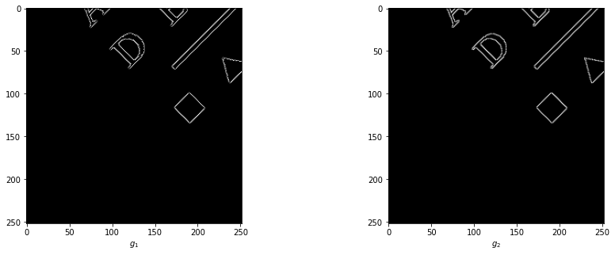

```python
fig, ax = pyplot.subplots(1, 2, figsize=(15, 5))
ax[0].imshow(g1)
ax[0].set_xlabel('$g_1$')
ax[1].imshow(g2)
ax[1].set_xlabel('$g_2$')

pyplot.show()
```

A ordem das operações não alterou o resultado (exceto nas bordas da imagem) portanto podemos dizer que **o operador Laplaciano é invariante à rotação**.

# Questão 7

A imagem original $f(x, y)$ (`lena.png`) foi corrompida por um ruído aditivo senoidal $\eta(x, y)$ resultando em $g(x, y)$ (`lena_noise.png`). Isto é, $g(x, y)=f(x, y)+\eta(x, y)$. Utilizando filtragem no domínio da frequência, obtenha uma estimativa $\hat{\eta}$ do ruído $\eta(x, y)$.

[figure not shown]

```python
lena_noise = cv2.imread('lena_noise.png', cv2.IMREAD_GRAYSCALE)
lena_noise = lena_noise.astype(numpy.float32) / 255.0

pyplot.imshow(lena_noise, cmap='gray', vmin=0, vmax=1.0)
pyplot.show()
```

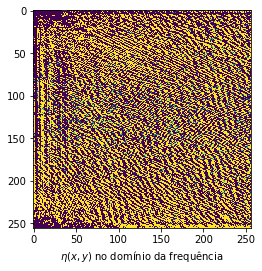

```python
dft = cv2.dft(lena_noise)

dft[dft[:, :] > 50] = 0

pyplot.imshow(dft, vmin=0, vmax=1.0)
pyplot.xlabel('$\eta(x, y)$ no domínio da frequência')
pyplot.show()
```